# HPI Bayesian Course

# Terms and abbreviations

- *RV*: random variable
- *Bernoulli* distribution: univariate binomial
- *PMF*: probability mass function (binomial)
- *CMF*: cumulative mass function (binomial)
- *standard normal distribution*: mean = 0, sd = 1
- *f* = *PDF*: probability density function (continuous)
- *CDF*: cumulative density function (continuous)
- *k*: number of successes
- *n*: number of trials
- $\theta$: the probability of success
- *AUC*: area under the curve
- *univariate*: one variable
- *bivariate*: 2 variables
- *multivariate*: 2+ variables
- *variance*: sd^2

# 1 Week 1

## 1.1 Discrete random variables

- random variables are functions that map one set to the set of real numbers
  - associates to each outcome to a particular real number

There’s a set of events that *can* happen, like tossing a coin. A random variable maps each of these possible events to a real number. In tossing a coin until you get a heads, a random variable would be the number of tosses until you get a ‘success’ (heads). In principle it could be an infinite set, bcause you could in theory toss the coin an infinite number of times without ever getting a heads (though this is extremely improbable).

Alternatively, the random variable can be a finite set if we are interested in looking whether *one* toss results in a head or a tails.

PMF: probability mass function, PDF: probability density function

- PMF = for discrete distributions
- PDF: for continuous
- CDF: cumulative distribution function; gives a mapping from a particular numerical value to a probability; means the probability of getting that number or something less than it.

Simulate tossing a coin 10 times with probability of heads = 0.5, with a Bernoulli random variable.

```r
# simulate tossing a coin 10 times
extraDistr::rbern(n = 10, prob = .5)
```

```
##  [1] 0 1 1 1 1 1 1 1 1 0
```

What’s the probablity of getting a tails or a heads? The d-family of functions:

```r
extraDistr::dbern(0,prob=.5)
```

```
## [1] 0.5
```

```r
extraDistr::dbern(1,prob=.5)
```

```
## [1] 0.5
```

Cumulative probability distribution function: the p-family of functions

```r
# probability distribution function

## for whichever case we coded as 0
extraDistr::pbern(0,.5)
```

```
## [1] 0.5
```

```r
## for whichever case we coded as 1
extraDistr::pbern(1,.5)
```

```
## [1] 1
```

## 1.2 Discrete random variables: the binomial

When we toss a coin only once, this is a Bernoulli random variable. If we toss the coin more than once, this is a *binomial*. Both Bernoulli and Binomial have a PMF associated with them.

```r
# generate random binomial data
rbinom(n = 10, size = 1, prob = .5)
```

```
##  [1] 0 0 1 1 0 1 0 1 1 1
```

```r
# compute probabilites of a particular outcome
probs <- round(dbinom(0:10, size = 10, prob = .5),3); probs
```

```
##  [1] 0.001 0.010 0.044 0.117 0.205 0.246 0.205 0.117 0.044 0.010 0.001
```

```r
x <- 0:10
rbind(x,probs)
```

```
##        [,1] [,2]  [,3]  [,4]  [,5]  [,6]  [,7]  [,8]  [,9] [,10]  [,11]
## x     0.000 1.00 2.000 3.000 4.000 5.000 6.000 7.000 8.000  9.00 10.000
## probs 0.001 0.01 0.044 0.117 0.205 0.246 0.205 0.117 0.044  0.01  0.001
```

```r
# compute cumulative probabilities of all possible outcomes
pbinom(0:10, size=10, prob = .5)
```

```
##  [1] 0.0009765625 0.0107421875 0.0546875000 0.1718750000 0.3769531250
##  [6] 0.6230468750 0.8281250000 0.9453125000 0.9892578125 0.9990234375
## [11] 1.0000000000
```

Compute quantiles using the inverse of the CDF: what is the quantile q such that the probability of X is greater than x?

```r
# generate distribution (0:10 outcomes or less, for 10 repetitions, with probability .5)
probs <- pbinom(0:10,size = 10, prob = .5)


# compute the inverse CDF; qbinom takes as its input a probability of an outcome and outputs the inverse
qbinom(probs, size = 10, prob=.5)
```

```
##  [1]  0  1  2  3  4  5  6  7  8  9 10
```

### 1.2.1 My summary notes

d-p-q-r family of functions

| RV | Function(arguments) | Outcome |
| --- | --- | --- |
| Bernoulli | `rbern(n,prob)` | generate random data |
|  | `dbern(x,prob)` | PMF: probability of outcome x |
|  | `pbern(q,prob)` | CMF: cumulative PDF of <=x |
| Binomial | `rbinom(n, size, prob)` | generate random data with n = of successes |
|  | `dbinom(q,size,prob)` | PMF: probability of outcome x |
|  | `pbinom(q,size,prob)` | CMF: cumulative PDF of <=x |
|  | `qbinom(prob,size)` | inverse CMF: cumulative PMF of >=x |
| normal | `rnorm(n,mean,sd)` | generate random data |
|  | `dnorm(x,mean,sd)` | PDF: probability of outcome x |
|  | `pnorm(q,mean,sd)` | CDF: cumulative PDF of <=x |
|  | `pnorm(q,mean,sd,` `lower.tail=F)` | inverse CDF: cumulative PDF of >=x |
|  | `qnorm(prob,size)` | Compute quantiles corresponding to probabilities |

## 1.3 Continuous random variables (PDFs)

- in discrete RV cases, we compute the probability of a *particular* outcome
- in continous RV cases, probability is defined by the *area under the curve* (AUC)
- we use the cumulative distribution function associated with a normal distribution to compute this AUC; i.e., the probability of observing a value between x1 and x2

## 1.4 Continous RVs: the normal distribution

- the standard normal distribution:
  - Normal(mean = 0, sd = 1)
  - Prob(-1 < X < 1) = 68%
  - Prob(-1.96 < X < 1.96) = 95%
  - Prob(-3 < X <3) = 99.7%
- for any other normal distribution (with varying mean and sd):
  - Prob(-1*sd < X < 1*sd ) = 68%
  - Prob(-1.96*sd < X < 1.96*sd ) = 95%
  - Prob(-3*sd < X <3*sd ) = 99.7%
- the continuous vales on the x-axis (here, |/- 1,2,3) are the **quantiles**

```r
rnorm(n=5,
      mean = 0,
      sd = 1)
```

```
## [1]  0.3194757 -1.7837062  0.5104529 -0.6058699 -2.0729487
```

`pnorm(q,mean,sd)`: Compute probabilities using CDF

```r
pnorm(q = 2,
      mean = 0,
      sd = 1)
```

```
## [1] 0.9772499
```

`pnorm(q,mean,sd,lower.tail=F)`: Compute inverse probabilities using CDF

```r
pnorm(q = 2,
      lower.tail=F,
      mean = 0,
      sd = 1) # don't look the left (equal to or less than q), but the right (equal or greater than q)
```

```
## [1] 0.02275013
```

`qnorm(p,mean,sd))`: Compute quantiles corresponding to probabilities using the inverse of the CDF

```r
qnorm(p = 0.9772499,
      mean = 0,
      sd = 1)
```

```
## [1] 2.000001
```

`dnorm(x,mean,sd)`: Compute the probability *density* for a quantile value - not the probability of a particular outcome - rather the **density** of that particular value, i.e., the y-axis value

```r
dnorm(x = 2,
      mean = 0,
      sd = 1)
```

```
## [1] 0.05399097
```

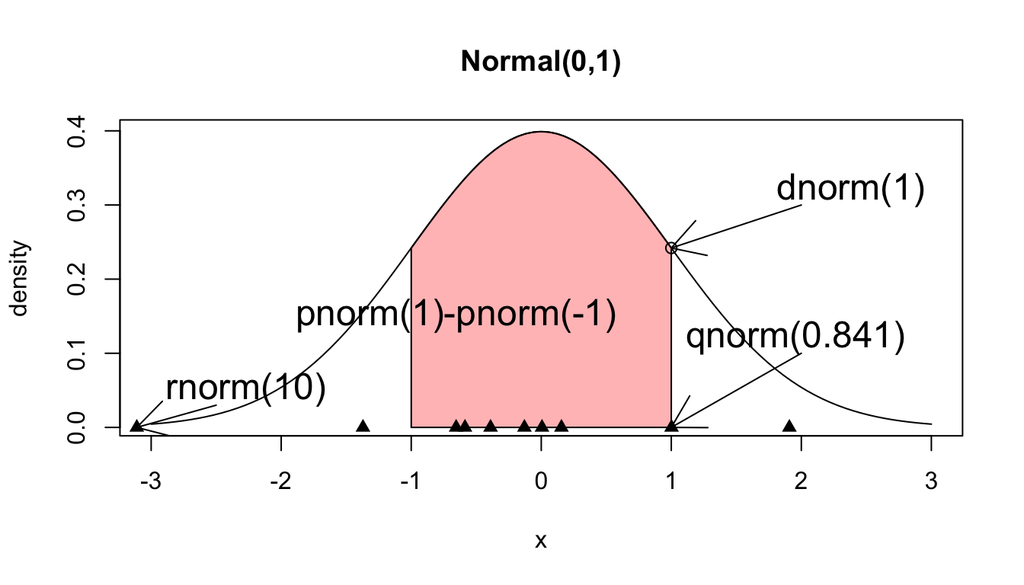

```r
curve(dnorm(x,0,1), xlim=c(-3,3), main="Normal(0,1)",
      ylab="density")
from.z <- -1
to.z <- 1
S.x  <- c(from.z, seq(from.z, to.z, 0.01), to.z)
S.y  <- c(0, dnorm(seq(from.z, to.z, 0.01)), 0)
polygon(S.x,S.y, col=rgb(1, 0, 0,0.3))
text(-2,0.15,pos=4,cex=1.5,paste("pnorm(1)-pnorm(-1)"))
arrows(x1=2,y1=0.3,x0=1,y0=dnorm(1),code = 1)
text(1.7,0.32,pos=4,cex=1.5,paste("dnorm(1)"))
points(1,dnorm(1))
#points(1,0)
arrows(x1=2,y1=0.1,x0=1,y0=0,code = 1)
text(1,0.12,pos=4,cex=1.5,paste("qnorm(0.841)"))
x<-rnorm(10)
points(x=x,y=rep(0,10),pch=17)
text(-3,0.05,pos=4,cex=1.5,paste("rnorm(10)"))
arrows(x1=-2.5,y1=0.03,x0=min(x),y0=0,code = 1)
```

## 1.5 Maximum Likelihood estimates

*Spoiler:* it’s pretty much the mean/mode/median of normally distributed data (where the three be the same); gives us the most likely value that the parameter $\theta$ has *given the data*

- the ‘expectation’ (discrete case)
- if you were to do an experment with a larger and larger sample size, you’d get closer to the expected value (e.g., value of .5 successes in repeated coin tosses)
- we can estimate $\theta$ ($\theta$-hat), but we’ll never know the true value of $\theta$

From my book notes from SMLP 2022:

> In real exerimental situations we never know the true value of $\theta$ (probability of an outcome), but it can be derived from the data: *$\theta$ hat = k/n*, where *k* = number of observed successess, *n* = number of trials, and *$\theta$ hat* = observed proportion of successes. *$\theta$ hat* = *maximum likelihood estimate* of the true but unknown parameter *$\theta$*. Basically, the **mean** of the binomial distribution. The **variance** can also be estimated by computing *(n($\theta$))(1 - $\theta$)*. These estimates can be be used for statistical inference. From my class notes from SMLP 2022:
> - common misunderstanding of the **maximum likelihood estimate (MLE)**: it doens’t represent the true value of $\theta$, because it’s the MLE (best guess) for the *data you have*
> - but the MLE will be closer to the true value of $\theta$ assample size increases
> - e.g., the PMF (binomial) contains three terms:
> - *k*: number of successes
> - *n*: total number of trials
> - *$\theta$*: probability of success (can have values between 0 and 1)
> - the PMF is a function of these parameters, based on the data (given our data we know the values of *k* and *n* so they are fixed quantities and no longer random), so $\theta$ can be treated as a variable
- the **likelihood function** is the PMF (or PDF) as a function of the parameters, rather than a function of the data
- the MLE from a particular *sample* of data doesn’t necessarily give us an accurate estimate of the true value of $\theta$ (because it’s just a sample, of course)
  - larger sample sizes get MLEs that more accurately represent the true value of $\theta$ (again, duh because of the point made above regarding the expectation)

## 1.6 Bivariate and multivariate distributions (Discrete case)

- *univariate* distributions: only one variab le
- *bivariate* or *multivariable* distributions: multiple variables
- *Bernoulli* distribution: univariate binomial data
- *joint probability mass function* (PMF): the joint distribution of multivariate binomial data
- joint probability density function would be for continuous data
- each RV has its own PMF that can be computed separately
- you can also compute the **conditional distribution**, i.e., the probability of x given y (x|y) or of y given x (x|y)
  - the conditional probability of *x|y* is going to be the joint distribution of *x,y* divided by the marginal distribution of a particular value of y

## 1.7 Bivariate and multivariate distributions (Continuous case)

- only going to discuss bivariate distributions here cause they’re easier to conceptualize
- we’d take into account the mean and sd of each variable, as well as the correlation between the two
- in a bivariate case, the diagonals (from top left downward) of the VarCorr matrix will contain the *variances* of either RV
  - the off-diagonals (from bottom left upward) contain the *covariance* from the two RVs
- *covariance* = the correlation of the two RVs multiplied by each of their SDs: *Cov(X,Y)* = $\rho$XY$\sigma$X$\sigma$Y
- this allows us to describe how these 2 RVs are jointly distributed
- in the joint PDF: AUC sums to 1 but will be a 3D cone, rather than a 2D curve as in the univariate case
- we can also compute the marginal distributions, just as in the bivariate discrete case
- simulating data:

```r
# generate simulated bivariate data

## define a VarCorr matrix, where rho = .6, variance
Sigma <- matrix(c(
  5^2, 5 * 10 * .6, # variance = sd^2, covariance=sd*sd*rho  (.6)
  .5 * 10 * .6, 10^2 # covariance=sd*sd*rho  (.6) * correlation (.6), variance = sd^2
  ),
  byrow = F, ncol = 2
  )

## generate data
u <- as.data.frame(MASS::mvrnorm(n = 100, mu = c(0,0), Sigma = Sigma))
head(u, n=3)
```

|  | V1 | V2 |
| --- | --- | --- |
| 1 | 5.5929969 | 24.39428 |
| 2 | -4.5429761 | -21.84952 |
| 3 | 0.3153321 | -12.14139 |

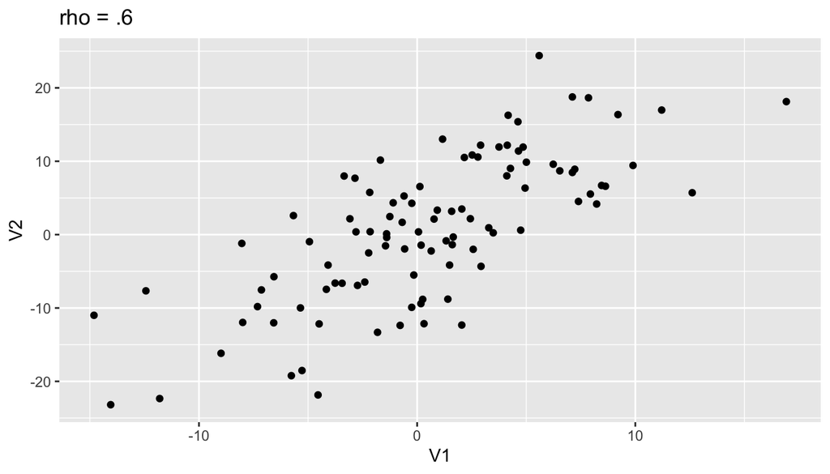

```r
## plot data
# plot(u)

ggplot2::ggplot(u, aes(x = V1, y = V2)) +
    labs(title = "rho = .6") +
    geom_point()
```